# Dimensionality reduction

Another week, another go. This is gonna be a short one, got sidetracked with actual work this week…

Starting with the setup for this week. New libraries: `stringr`, `FactoMiner`.

```r
# Used knitr options: No "##" before output
library(dplyr)
library(ggplot2)
library(GGally)
library(gridExtra)
library(reshape2)
library(tidyr)
library(corrplot)
library(stringr)
library(FactoMineR)  # Contains the "tea" dataset
```

## Data overview

This time we’re having a wrangled dataset! See the creation script [here](https://github.com/pkars/IODS-project/blob/master/data/create_human.R). Original data is from Human Development Reports by United Nations Development Programme, see http://hdr.undp.org/en/content/human-development-index-hdi . Datasets used in the data wrangling were provided by IODS lecturers.

Starting with the data overview, first is the classic table of columns and their meaning:

| Variable | Meaning | Type | Notes |
| --- | --- | --- | --- |
| `edu2.ratio` | Females-to-males ratio of people with secondary or higher education | num | `edu2.F / edu2.M` |
| `lab.ratio` | Females-to-males ratio of people in the work force | num | `lab.F / lab.M` |
| `exp.edu.years` | Expected years in education | num |  |
| `exp.life.years` | Life expectancy at birth | num |  |
| `GNI` | Gross National Income per capita | num |  |
| `mat.mort.rate` | Maternal mortality rate | int |  |
| `adol.birth.rate` | Adolescent birth rate | num |  |
| `parl.F.ratio` | Ratio of females in the parliament | num |  |

```r
dataset <- read.csv("data/human.csv", header=TRUE, row.names=1)
str(dataset)
```

```
'data.frame':   155 obs. of  8 variables:
 $ edu2.ratio     : num  1.007 0.997 0.983 0.989 0.969 ...
 $ lab.ratio      : num  0.891 0.819 0.825 0.884 0.829 ...
 $ exp.edu.years  : num  17.5 20.2 15.8 18.7 17.9 16.5 18.6 16.5 15.9 19.2 ...
 $ exp.life.years : num  81.6 82.4 83 80.2 81.6 80.9 80.9 79.1 82 81.8 ...
 $ GNI            : int  64992 42261 56431 44025 45435 43919 39568 52947 42155 32689 ...
 $ mat.mort.rate  : int  4 6 6 5 6 7 9 28 11 8 ...
 $ adol.birth.rate: num  7.8 12.1 1.9 5.1 6.2 3.8 8.2 31 14.5 25.3 ...
 $ parl.F.ratio   : num  39.6 30.5 28.5 38 36.9 36.9 19.9 19.4 28.2 31.4 ...
```

```r
summary(dataset)
```

```
   edu2.ratio       lab.ratio      exp.edu.years   exp.life.years
 Min.   :0.1717   Min.   :0.1857   Min.   : 5.40   Min.   :49.00
 1st Qu.:0.7264   1st Qu.:0.5984   1st Qu.:11.25   1st Qu.:66.30
 Median :0.9375   Median :0.7535   Median :13.50   Median :74.20
 Mean   :0.8529   Mean   :0.7074   Mean   :13.18   Mean   :71.65
 3rd Qu.:0.9968   3rd Qu.:0.8535   3rd Qu.:15.20   3rd Qu.:77.25
 Max.   :1.4967   Max.   :1.0380   Max.   :20.20   Max.   :83.50
      GNI         mat.mort.rate    adol.birth.rate   parl.F.ratio
 Min.   :   581   Min.   :   1.0   Min.   :  0.60   Min.   : 0.00
 1st Qu.:  4198   1st Qu.:  11.5   1st Qu.: 12.65   1st Qu.:12.40
 Median : 12040   Median :  49.0   Median : 33.60   Median :19.30
 Mean   : 17628   Mean   : 149.1   Mean   : 47.16   Mean   :20.91
 3rd Qu.: 24512   3rd Qu.: 190.0   3rd Qu.: 71.95   3rd Qu.:27.95
 Max.   :123124   Max.   :1100.0   Max.   :204.80   Max.   :57.50
```

```r
knitr::kable(head(dataset, 5))
```

|  | edu2.ratio | lab.ratio | exp.edu.years | exp.life.years | GNI | mat.mort.rate | adol.birth.rate | parl.F.ratio |
| --- | --- | --- | --- | --- | --- | --- | --- | --- |
| Norway | 1.0072389 | 0.8908297 | 17.5 | 81.6 | 64992 | 4 | 7.8 | 39.6 |
| Australia | 0.9968288 | 0.8189415 | 20.2 | 82.4 | 42261 | 6 | 12.1 | 30.5 |
| Switzerland | 0.9834369 | 0.8251001 | 15.8 | 83.0 | 56431 | 6 | 1.9 | 28.5 |
| Denmark | 0.9886128 | 0.8840361 | 18.7 | 80.2 | 44025 | 5 | 5.1 | 38.0 |
| Netherlands | 0.9690608 | 0.8286119 | 17.9 | 81.6 | 45435 | 6 | 6.2 | 36.9 |

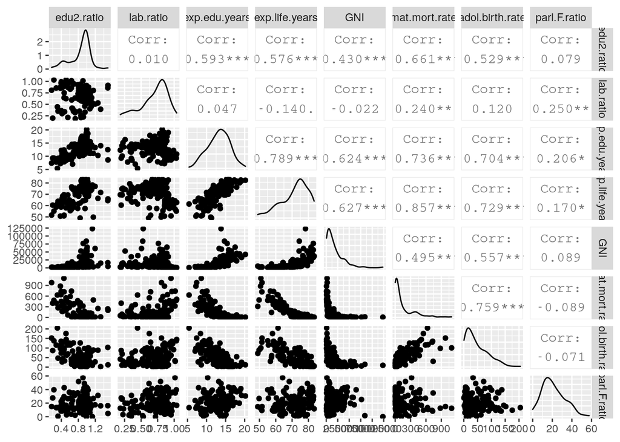

```r
ggpairs(dataset)
```

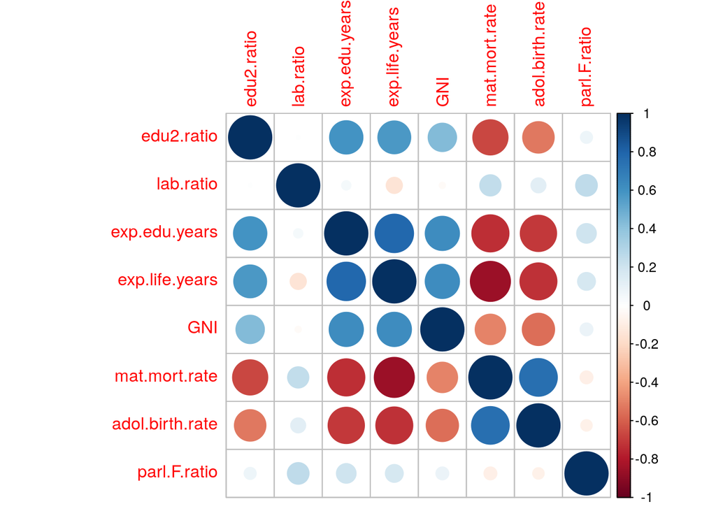

```r
cor(dataset)%>% corrplot
```

Looking at the median of education and labor ratios, they are under one, meaning that more men than women are both educated and involved in the labor force. However, the education ratio median is close to one, but the 3rd quantile is also under one. Maternal mortality rate and adolescent birth rate are correlating with each other positively and negatively with life expectancy, education and GNI.

## Principal component analysis

First, I’ll perform principal component analysis (PCA) using the singular value decomposition, but without scaling the dataset.

```r
pca_unscaled <- prcomp(dataset)
pca_unscaled
```

```
Standard deviations (1, .., p=8):
[1] 1.854416e+04 1.855219e+02 2.518701e+01 1.145441e+01 3.766241e+00
[6] 1.565912e+00 1.912052e-01 1.591112e-01

Rotation (n x k) = (8 x 8):
                          PC1           PC2           PC3           PC4
edu2.ratio      -5.607472e-06  0.0006713951 -3.412027e-05 -2.736326e-04
lab.ratio        2.331945e-07 -0.0002819357  5.302884e-04 -4.692578e-03
exp.edu.years   -9.562910e-05  0.0075529759  1.427664e-02 -3.313505e-02
exp.life.years  -2.815823e-04  0.0283150248  1.294971e-02 -6.752684e-02
GNI             -9.999832e-01 -0.0057723054 -5.156742e-04  4.932889e-05
mat.mort.rate    5.655734e-03 -0.9916320120  1.260302e-01 -6.100534e-03
adol.birth.rate  1.233961e-03 -0.1255502723 -9.918113e-01  5.301595e-03
parl.F.ratio    -5.526460e-05  0.0032317269 -7.398331e-03 -9.971232e-01
                          PC5           PC6           PC7           PC8
edu2.ratio      -0.0022935252  2.180183e-02  6.998623e-01  7.139410e-01
lab.ratio        0.0022190154  3.264423e-02  7.132267e-01 -7.001533e-01
exp.edu.years    0.1431180282  9.882477e-01 -3.826887e-02  7.776451e-03
exp.life.years   0.9865644425 -1.453515e-01  5.380452e-03  2.281723e-03
GNI             -0.0001135863 -2.711698e-05 -8.075191e-07 -1.176762e-06
mat.mort.rate    0.0266373214  1.695203e-03  1.355518e-04  8.371934e-04
adol.birth.rate  0.0188618600  1.273198e-02 -8.641234e-05 -1.707885e-04
parl.F.ratio    -0.0716401914 -2.309896e-02 -2.642548e-03  2.680113e-03
```

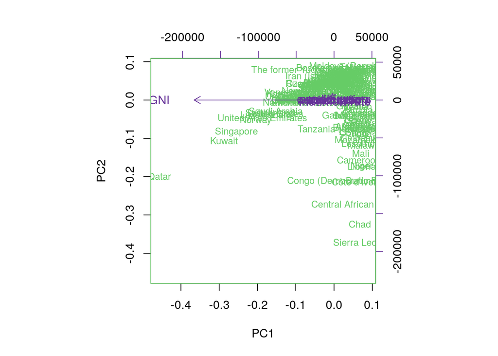

```r
# Drawing the biplot for the first 2 PCA dimensions
biplot(pca_unscaled, choices = 1:2, cex=c(0.8,1), col=c("#66CC66", "#663399")) # purple color is "rebecca"
```

Yup, that’s a mess. PCA expects that the variable values are of similar scales, so having a `GNI` column that is about 3-4 magnitudes larger than other variables causes this.

```r
scaled <- scale(dataset)
pca_scaled <- prcomp(scaled)
pca_scaled
```

```
Standard deviations (1, .., p=8):
[1] 2.0708380 1.1397204 0.8750485 0.7788630 0.6619563 0.5363061 0.4589994
[8] 0.3222406

Rotation (n x k) = (8 x 8):
                        PC1         PC2         PC3         PC4        PC5
edu2.ratio      -0.35664370  0.03796058 -0.24223089  0.62678110 -0.5983585
lab.ratio        0.05457785  0.72432726 -0.58428770  0.06199424  0.2625067
exp.edu.years   -0.42766720  0.13940571 -0.07340270 -0.07020294  0.1659678
exp.life.years  -0.44372240 -0.02530473  0.10991305 -0.05834819  0.1628935
GNI             -0.35048295  0.05060876 -0.20168779 -0.72727675 -0.4950306
mat.mort.rate    0.43697098  0.14508727 -0.12522539 -0.25170614 -0.1800657
adol.birth.rate  0.41126010  0.07708468  0.01968243  0.04986763 -0.4672068
parl.F.ratio    -0.08438558  0.65136866  0.72506309  0.01396293 -0.1523699
                        PC6         PC7         PC8
edu2.ratio       0.17713316  0.05773644  0.16459453
lab.ratio       -0.03500707 -0.22729927 -0.07304568
exp.edu.years   -0.38606919  0.77962966 -0.05415984
exp.life.years  -0.42242796 -0.43406432  0.62737008
GNI              0.11120305 -0.13711838 -0.16961173
mat.mort.rate    0.17370039  0.35380306  0.72193946
adol.birth.rate -0.76056557 -0.06897064 -0.14335186
parl.F.ratio     0.13749772  0.00568387 -0.02306476
```

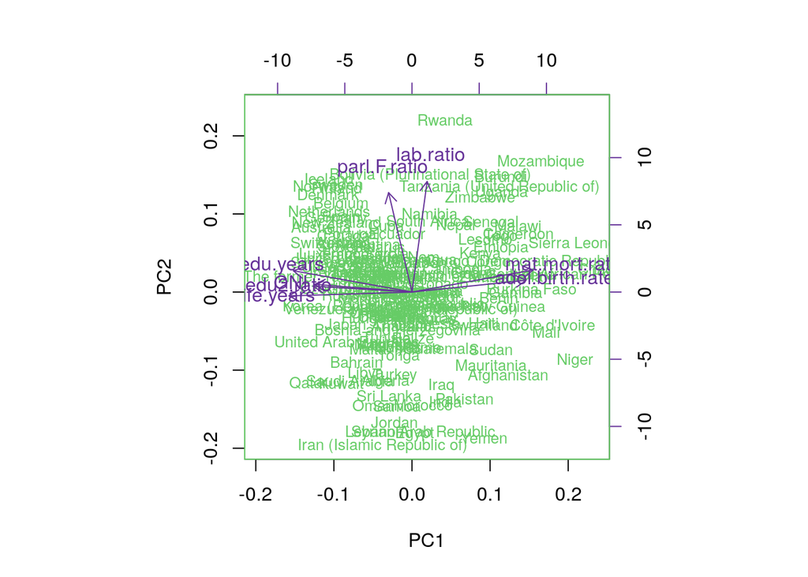

```r
# Drawing the biplot for the first 2 PCA dimensions
biplot(pca_scaled, choices = 1:2, cex=c(0.8,1), col=c("#66CC66", "#663399")) # purple color is "rebecca"
```

Now this looks a bit better. Based on this analysis, country’s healthcare (life expectancy, maternal mortality, adolescent pregnancies), education of women, and income levels are the most significant indicators in this particular dataset. The first dimension is women education and healthcare axis: more rich and educated countries have better healthcare than poor countries. Or that educated women have less pregnancies. The second dimension is about how much women are involved with the society - are they working or are they staying at home (for any reason)? Are women in positions of power?

## Multiple Correspondence Analysis

Wrapping up this week is multiple correspondence analysis (MCA). For this analysis, we’re using the `tea` dataset from FactoMineR library. It is a dataset of questionnaire answers regarding tea According to the documentation, the questionnaire asked 300 individuals about their tea-drinking habits (18 questions), their product’s perception (12 questions) and personal details (4 questions). So, the data has 300 rows and 36 columns, with each individual on one row and each question in their own column.

```r
# using `tea` dataset from FactoMineR library
data(tea)
str(tea)
```

```
'data.frame':   300 obs. of  36 variables:
 $ breakfast       : Factor w/ 2 levels "breakfast","Not.breakfast": 1 1 2 2 1 2 1 2 1 1 ...
 $ tea.time        : Factor w/ 2 levels "Not.tea time",..: 1 1 2 1 1 1 2 2 2 1 ...
 $ evening         : Factor w/ 2 levels "evening","Not.evening": 2 2 1 2 1 2 2 1 2 1 ...
 $ lunch           : Factor w/ 2 levels "lunch","Not.lunch": 2 2 2 2 2 2 2 2 2 2 ...
 $ dinner          : Factor w/ 2 levels "dinner","Not.dinner": 2 2 1 1 2 1 2 2 2 2 ...
 $ always          : Factor w/ 2 levels "always","Not.always": 2 2 2 2 1 2 2 2 2 2 ...
 $ home            : Factor w/ 2 levels "home","Not.home": 1 1 1 1 1 1 1 1 1 1 ...
 $ work            : Factor w/ 2 levels "Not.work","work": 1 1 2 1 1 1 1 1 1 1 ...
 $ tearoom         : Factor w/ 2 levels "Not.tearoom",..: 1 1 1 1 1 1 1 1 1 2 ...
 $ friends         : Factor w/ 2 levels "friends","Not.friends": 2 2 1 2 2 2 1 2 2 2 ...
 $ resto           : Factor w/ 2 levels "Not.resto","resto": 1 1 2 1 1 1 1 1 1 1 ...
 $ pub             : Factor w/ 2 levels "Not.pub","pub": 1 1 1 1 1 1 1 1 1 1 ...
 $ Tea             : Factor w/ 3 levels "black","Earl Grey",..: 1 1 2 2 2 2 2 1 2 1 ...
 $ How             : Factor w/ 4 levels "alone","lemon",..: 1 3 1 1 1 1 1 3 3 1 ...
```

[output cut: 22 more lines]

```r
summary(tea)
```

```
         breakfast           tea.time          evening          lunch
 breakfast    :144   Not.tea time:131   evening    :103   lunch    : 44
 Not.breakfast:156   tea time    :169   Not.evening:197   Not.lunch:256





        dinner           always          home           work
 dinner    : 21   always    :103   home    :291   Not.work:213
 Not.dinner:279   Not.always:197   Not.home:  9   work    : 87





        tearoom           friends          resto          pub
 Not.tearoom:242   friends    :196   Not.resto:221   Not.pub:237
 tearoom    : 58   Not.friends:104   resto    : 79   pub    : 63





        Tea         How           sugar                     how
 black    : 74   alone:195   No.sugar:155   tea bag           :170
 Earl Grey:193   lemon: 33   sugar   :145   tea bag+unpackaged: 94
 green    : 33   milk : 63                  unpackaged        : 36
                 other:  9



                  where                 price          age        sex
 chain store         :192   p_branded      : 95   Min.   :15.00   F:178
 chain store+tea shop: 78   p_cheap        :  7   1st Qu.:23.00   M:122
 tea shop            : 30   p_private label: 21   Median :32.00
                            p_unknown      : 12   Mean   :37.05
                            p_upscale      : 53   3rd Qu.:48.00
                            p_variable     :112   Max.   :90.00

```

[output cut: 20 more lines]

```




         feminine             sophisticated        slimming          exciting
 feminine    :129   Not.sophisticated: 85   No.slimming:255   exciting   :116
 Not.feminine:171   sophisticated    :215   slimming   : 45   No.exciting:184





        relaxing              effect.on.health
 No.relaxing:113   effect on health   : 66
 relaxing   :187   No.effect on health:234
```

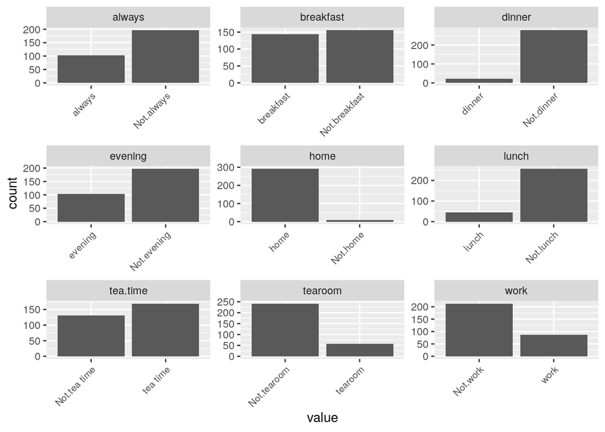

```r
tea_no_age <- select(tea, -age)

tea_no_age %>% select(1:9) %>% pivot_longer(cols=everything(), names_to="key", values_to="value") %>% ggplot(aes(value)) + facet_wrap("key", scales = "free") + geom_bar() + theme(axis.text.x = element_text(angle = 45, hjust = 1, size = 8))
```

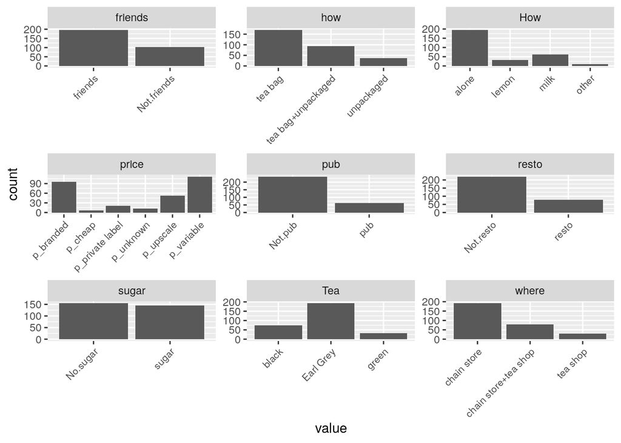

```r
tea_no_age %>% select(10:18) %>% pivot_longer(cols=everything(), names_to="key", values_to="value") %>% ggplot(aes(value)) + facet_wrap("key", scales = "free") + geom_bar() + theme(axis.text.x = element_text(angle = 45, hjust = 1, size = 8))
```

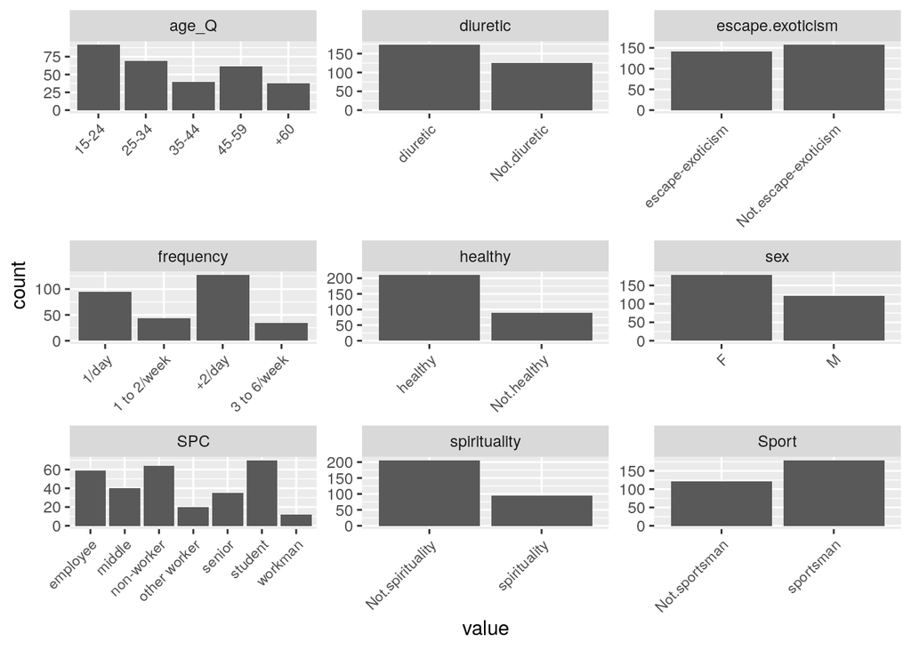

```r
tea_no_age %>% select(19:27) %>% pivot_longer(cols=everything(), names_to="key", values_to="value") %>% ggplot(aes(value)) + facet_wrap("key", scales = "free") + geom_bar() + theme(axis.text.x = element_text(angle = 45, hjust = 1, size = 8))
```

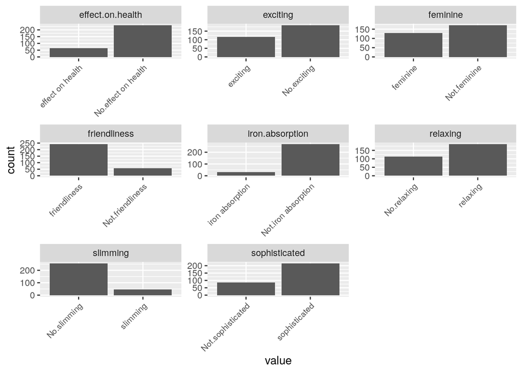

```r
tea_no_age %>% select(28:35) %>% pivot_longer(cols=everything(), names_to="key", values_to="value") %>% ggplot(aes(value)) + facet_wrap("key", scales = "free") + geom_bar() + theme(axis.text.x = element_text(angle = 45, hjust = 1, size = 8))
```

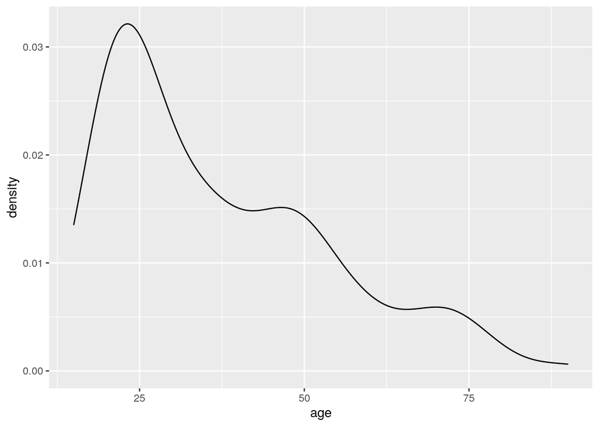

```r
tea %>% ggplot(aes(age)) + geom_density()
```

Looks to be an interesting dataset, though it’s a bit difficult to properly visualise. Let’s pick a few columns and perform MCA to them.

```r
keep_cols <- c("age_Q", "sex", "frequency", "Tea", "price", "sugar", "How")
data <- select(tea, one_of(keep_cols))
mca <- MCA(data, graph=FALSE)
mca$eig
```

```
       eigenvalue percentage of variance cumulative percentage of variance
dim 1  0.25377239               9.349509                          9.349509
dim 2  0.21962466               8.091435                         17.440944
dim 3  0.19242745               7.089432                         24.530377
dim 4  0.18126192               6.678071                         31.208447
dim 5  0.17107329               6.302700                         37.511147
dim 6  0.16281205               5.998339                         43.509486
dim 7  0.15351935               5.655976                         49.165462
dim 8  0.14892416               5.486680                         54.652142
dim 9  0.13900476               5.121228                         59.773370
dim 10 0.13855325               5.104593                         64.877963
dim 11 0.12861410               4.738414                         69.616377
dim 12 0.12434570               4.581157                         74.197535
dim 13 0.12112984               4.462678                         78.660213
dim 14 0.12094719               4.455949                         83.116162
dim 15 0.11055570               4.073105                         87.189267
dim 16 0.10387947               3.827138                         91.016405
dim 17 0.08964207               3.302603                         94.319008
dim 18 0.08046729               2.964584                         97.283592
dim 19 0.07373107               2.716408                        100.000000
```

```r
mca$var$contrib
```

```
                       Dim 1       Dim 2        Dim 3      Dim 4       Dim 5
15-24           7.913377e+00 10.97033963  1.708701684  1.9968789  2.07232894
25-34           4.056933e+00  7.85507712  0.071367598 12.0683981  1.93779594
35-44           1.446520e+00  0.27107440  0.355201941  4.6803402 18.16844062
45-59           4.541041e+00  0.15278159 14.827082242  0.4401140  0.03107965
+60             9.968695e+00  1.79028331  6.724952355  0.3337406 14.33152539
F               6.581611e-01 14.09573560  0.110315981  0.1234269  0.49893018
M               9.602678e-01 20.56590932  0.160952824  0.1800818  0.72794731
1/day           1.824514e+00  3.78037554 11.165695773  0.1886927  0.89022035
1 to 2/week     2.479474e+00  1.25863987  5.960546982  0.2467699  0.38723509
+2/day          3.942764e+00  5.11421794  0.104603818  0.1316144  0.45963324
3 to 6/week     4.474078e-02  0.02420935  4.765988678  0.3481716  4.75035719
black           1.515701e+01  3.18701783  1.741831467  5.1900990  0.23013408
Earl Grey       7.428548e+00  2.99324399  0.098507993  0.1065889  0.06568091
green           5.796958e-01  2.28218164  7.482241840 17.6488807  1.79066476
p_branded       7.263746e-01  1.51913249  6.766248448  0.2991279  6.29340604
p_cheap         2.045066e-01  0.35175914  0.896865300  5.3912908 12.86899210
p_private label 1.432982e+00  0.42811026  0.006741122  1.3641797  1.13413645
p_unknown       1.516061e+00  3.10008365  3.879587807 17.0230069  1.91080210
p_upscale       7.190898e+00  6.11545398  0.646959738  2.4477659  0.18756054
p_variable      6.321193e-02  1.63170789  4.905228919  0.7340771 12.34728571
No.sugar        1.012510e+01  1.95243120  3.827438813  0.5567729  1.51225785
sugar           1.082338e+01  2.08708163  4.091400111  0.5951710  1.61655149
alone           1.149679e-01  2.86953762  0.063490448  5.8662485  2.90514235
lemon           3.009857e-01  1.93018383  6.575250633  0.8332322 12.64607902
milk            9.033844e-04  3.64282402  5.882342043 18.8400640  0.22131975
other           6.498879e+00  0.03060716  7.180455442  2.3652654  0.01449295
```

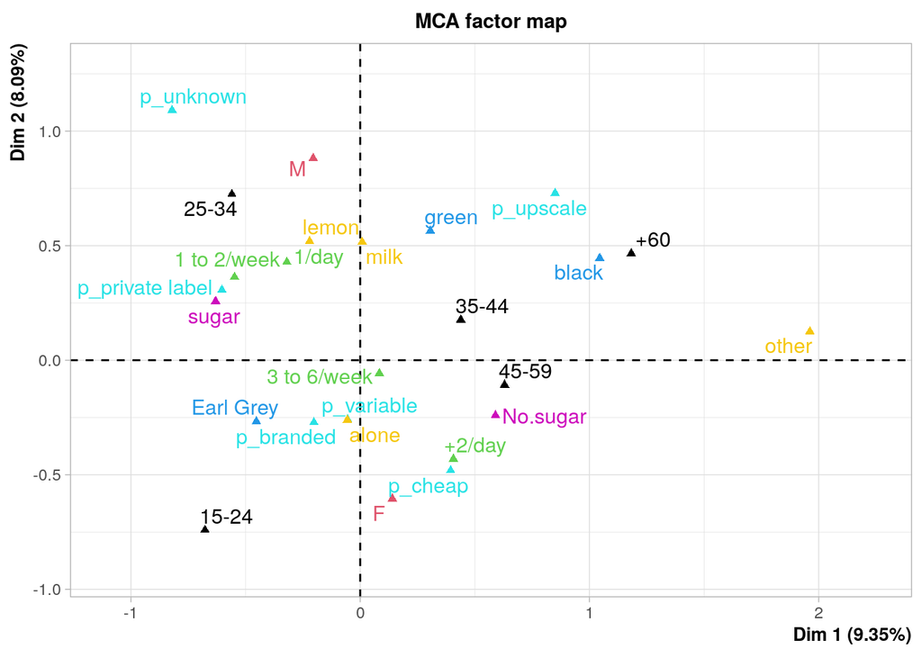

```r
plot(mca, invisible=c("ind"), habillage="quali")
```

So I decided to go with person’s age and gender, how often they drink tea, what kind of tea they drink, how expensive their tea is, and if they add something (sugar, milk) to their tea. So, putting those in and taking the model out, let’s see… Okay, so my set of variables wasn’t very good. The first two dimensions explain only 17.4% of the (cumulative) variance! So it is probably no wonder the biplot looks like a scatterplot where the dots are all over the place.

This week’s diary has been really short compared to other weeks… Well, such is life, there’s so much to do and so little time.